# movies

# Asking questions

```python
# Q1: Which genres are most popular from year to year?
# Q2: What kinds of properties are associated with movies that have high revenues?
# Q3: what are more popular long movies or short movies?
# Q4: who is the most successful director 1960-2015 highest revenue_adj (average)?
# Q5: who (director) has the most popular movies from 2001-2015?
# Q6: who (director) has the highest vote average from 2001-2015?
# Q7: who (director) has the highest vote average from 2001-2015 for directors has participated in more than 3 movies?
```

# EDA

```python
# define two lists ,mylist contains average popularity of each genre
```

```python
mylist=[]
years=[]
for year in df['release_year'].unique():
    mylist.append(df.query(f'release_year == {year}').groupby('main_genres')['popularity'].mean())
    years.append(year)
```

```python
# list contains highest pop for years from 2015 ,2014 ,...
```

```python
highest_pop=[]
for i in mylist:
    highest_pop.append(i.max())
```

```python
type(mylist[0])
```

```
pandas.core.series.Series
```

```python
newlist=[]
for i in mylist:
    newlist.append(i.to_frame())
```

```python
highest_pop_df=[]
for ind in range(len(newlist)):
    highest_pop_df.append(newlist[ind].query(f'popularity == {highest_pop[ind]}'))
```

```python
print(str(highest_pop_df[2].popularity).split('    ')[0][12:])
```

```
Adventure
```

```python
# define list contains popular genre
```

```python
popular_genres=[]
for i in range(len(highest_pop_df)):
    popular_genres.append(str(highest_pop_df[i].popularity).split('    ')[0][12:])
```

```python
len(popular_genres)
```

```
56
```

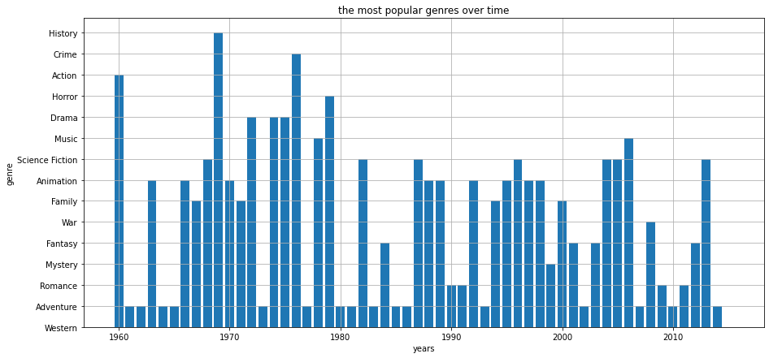

```python
plt.figure(figsize=(15, 7))
plt.grid(True)
plt.title('the most popular genres over time')
plt.xlabel('years')
plt.ylabel('genre')
plt.bar(years,popular_genres);
```

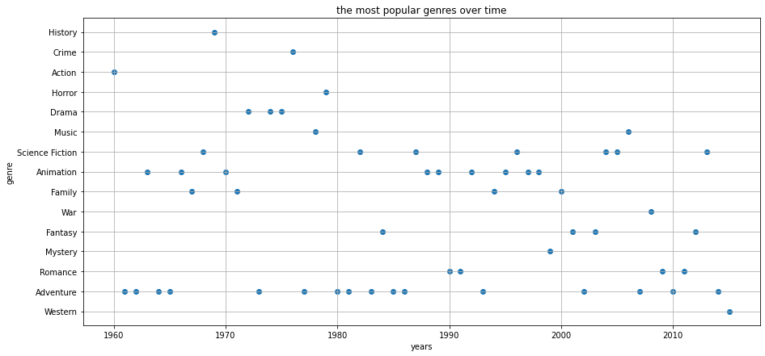

```python
plt.figure(figsize=(15, 7))
plt.grid(True)
plt.title('the most popular genres over time')
plt.xlabel('years')
plt.ylabel('genre')
plt.scatter(years,popular_genres);
```

## this plot shows the most popular genre from year to year (maximum average popularity)

## These points point to the most popular genre of this year.

```python
newlist[0]['main_genres']=newlist[0].index
```

```python
for i in range(len(newlist)):
    newlist[i]['main_genres']=newlist[i].index
# this loop to can access main_genres because it was used as index
```

```python
for i in range(len(newlist)):
    newlist[i]['main_genres']=newlist[i]['main_genres'].apply(lambda x:x.lower().strip().replace(' ','_'))
```

```python
type(newlist[0].main_genres[0])
```

```
str
```

```python
all_genres_str = newlist[0]['main_genres']
all_genres_str[0]
```

```
'action'
```

```python
#  The next 2 cells were quite challenging
#  I want to show the most popular genre over time with a second way
#  define a list for every genre contains average popularity year to year
#  nested for loop
#  newlist loop for every year contains a frame of {'genre':'popularity average'}
#  all_genres loop for every genre(list) to append popularity average in this year
```

```python
action=[]
adventure=[]
animation=[]
comedy=[]
crime=[]
documentary=[]
drama=[]
family=[]
fantasy=[]
history=[]
horror=[]
music=[]
mystery=[]
romance=[]
science_fiction=[]
tv_movie=[]
thriller=[]
war=[]
western=[]

all_genres=[action,adventure,animation,comedy,crime,documentary,drama,family,fantasy,history,horror,music,mystery,romance,science_fiction,tv_movie,thriller,war,western]
```

```python
for i in range(len(newlist)):
    for c in range(len(all_genres)):
        try:
            all_genres[c].append(newlist[i].query(f'main_genres == "{all_genres_str[c]}"')['popularity'][0])
        except:
            all_genres[c].append(float(0))
```

```python
# loop to plot all genres in the same fig instead of writing code manually
```

```python
for gen in all_genres_str:
    print(f'plt.bar(years,{gen},label = "{gen}")')
```

```
plt.bar(years,action,label = "action")
plt.bar(years,adventure,label = "adventure")
plt.bar(years,animation,label = "animation")
plt.bar(years,comedy,label = "comedy")
plt.bar(years,crime,label = "crime")
plt.bar(years,documentary,label = "documentary")
plt.bar(years,drama,label = "drama")
plt.bar(years,family,label = "family")
plt.bar(years,fantasy,label = "fantasy")
plt.bar(years,history,label = "history")
plt.bar(years,horror,label = "horror")
plt.bar(years,music,label = "music")
plt.bar(years,mystery,label = "mystery")
plt.bar(years,romance,label = "romance")
plt.bar(years,science_fiction,label = "science_fiction")
plt.bar(years,tv_movie,label = "tv_movie")
plt.bar(years,thriller,label = "thriller")
plt.bar(years,war,label = "war")
plt.bar(years,western,label = "western")
```

## The most popular genres over time

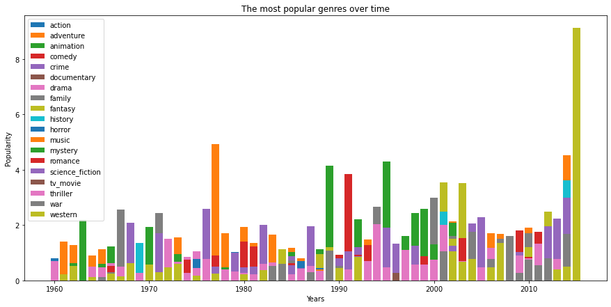

```python
plt.figure(figsize=(15, 7))
plt.bar(years,action,label = "action")
plt.bar(years,adventure,label = "adventure")
plt.bar(years,animation,label = "animation")
plt.bar(years,comedy,label = "comedy")
plt.bar(years,crime,label = "crime")
plt.bar(years,documentary,label = "documentary")
plt.bar(years,drama,label = "drama")
plt.bar(years,family,label = "family")
plt.bar(years,fantasy,label = "fantasy")
plt.bar(years,history,label = "history")
plt.bar(years,horror,label = "horror")
plt.bar(years,music,label = "music")
plt.bar(years,mystery,label = "mystery")
plt.bar(years,romance,label = "romance")
plt.bar(years,science_fiction,label = "science_fiction")
plt.bar(years,tv_movie,label = "tv_movie")
plt.bar(years,thriller,label = "thriller")
plt.bar(years,war,label = "war")
plt.bar(years,western,label = "western")
plt.xlabel("Years")
plt.ylabel("Popularity")
plt.title("The most popular genres over time")
plt.legend()
plt.show()
```

## You can notice the dominant color every year that expresses the most popular genre of this year.

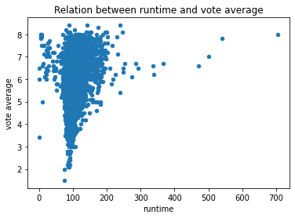

```python
df.plot(kind='scatter',y='vote_average',x="runtime");
plt.title('Relation between runtime and vote average')
plt.xlabel('runtime')
plt.ylabel('vote average')
plt.show()
```

```python
print(df.query(f'runtime > {df.runtime.median()}')['vote_average'].mean().round(3))
print(df.query(f'runtime <= {df.runtime.median()}')['vote_average'].mean().round(3))
```

```
6.284
5.761
```

### long movies have a higher vote average and higher popularity also

```python
print(df.query(f'runtime > {df.runtime.median()}')['popularity'].mean().round(3))
print(df.query(f'runtime <= {df.runtime.median()}')['popularity'].mean().round(3))
```

```
1.054
0.62
```

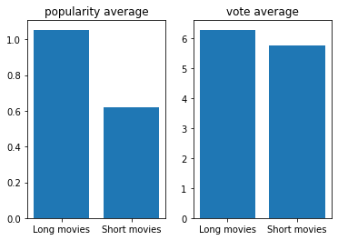

```python
movies=['Long movies','Short movies']
pop_movies=[1.054,0.62]
vote_movies=[6.284,5.761]
plt.figure()
plt.subplot(121)
plt.bar(movies,pop_movies)
plt.title('popularity average')

plt.subplot(122)
plt.bar(movies,vote_movies)
plt.title('vote average')
plt.show()
```

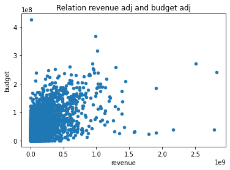

```python
df.plot(kind='scatter',x='revenue_adj',y='budget_adj');
plt.title('Relation revenue adj and budget adj')
plt.ylabel('budget')
plt.xlabel('revenue')
plt.show()
```

```python
df.head(1)
```

|  | id | imdb_id | popularity | budget | revenue | original_title | cast | director | tagline | keywords | ... | runtime | genres | production_companies | release_date | vote_count | vote_average | release_year | budget_adj | revenue_adj | main_genres |
| --- | --- | --- | --- | --- | --- | --- | --- | --- | --- | --- | --- | --- | --- | --- | --- | --- | --- | --- | --- | --- | --- |
| 0 | 135397 | tt0369610 | 32.985763 | 150000000 | 1513528810 | Jurassic World | Chris Pratt\|Bryce Dallas Howard\|Irrfan Khan\|Vi... | Colin Trevorrow | The park is open. | monster\|dna\|tyrannosaurus rex\|velociraptor\|island | ... | 124 | Action\|Adventure\|Science Fiction\|Thriller | Universal Studios\|Amblin Entertainment\|Legenda... | 6/9/15 | 5562 | 6.5 | 2015 | 1.379999e+08 | 1.392446e+09 | Action |

1 rows × 21 columns

## exploring properties is associated with movies that have high revenues

### I think that budget and popularity have a positive correlation with revenue.

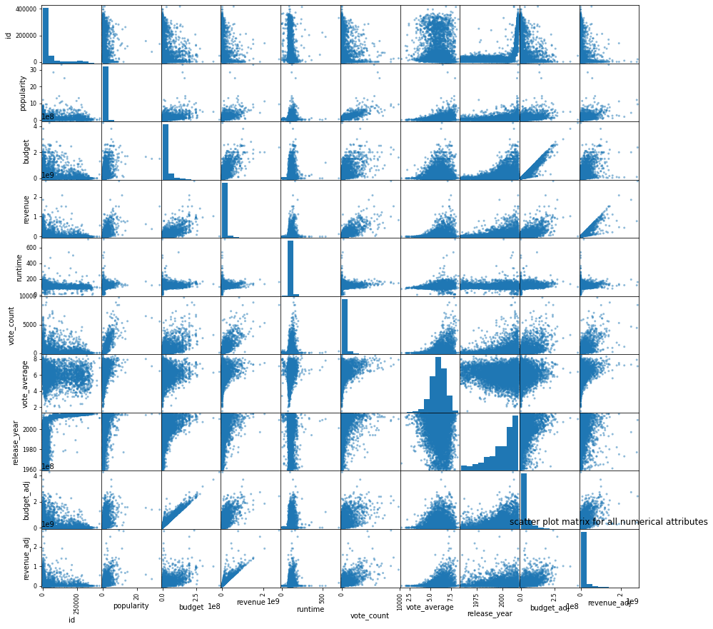

```python
pd.plotting.scatter_matrix(df, figsize = (15,15));
# plt.title('scatter plot matrix for all numerical attributes')
# the printed in the fig so i commented this line
plt.show()
```

```python
new_df=df.groupby('director').revenue_adj.mean()
new_df.to_frame().head()
```

| director | revenue_adj |
| --- | --- |
| Aaron Blaise\|Robert Walker | 2.963382e+02 |
| Aaron Hann\|Mario Miscione | 0.000000e+00 |
| Aaron Harvey | 0.000000e+00 |
| Aaron Katz\|Martha Stephens | 0.000000e+00 |
| Aaron Norris | 6.290942e+06 |

```python
new_df=new_df.to_frame()
```

```python
new_df['director']=new_df.index
```

```python
new_df.revenue_adj.max()
```

```
1574814739.70476
```

# the most successful director 1960-2015 highest revenue_adj (average)

```python
new_df.query('revenue_adj == 1574814739.70476')['director'][0]
```

```
'Clyde Geronimi|Hamilton Luske|Wolfgang Reitherman'
```

### Let's know more about the last 15 years

```python
df_01 = df.query('release_year > 2000')
df_01.head()
```

|  | id | imdb_id | popularity | budget | revenue | original_title | cast | director | tagline | keywords | ... | runtime | genres | production_companies | release_date | vote_count | vote_average | release_year | budget_adj | revenue_adj | main_genres |
| --- | --- | --- | --- | --- | --- | --- | --- | --- | --- | --- | --- | --- | --- | --- | --- | --- | --- | --- | --- | --- | --- |
| 0 | 135397 | tt0369610 | 32.985763 | 150000000 | 1513528810 | Jurassic World | Chris Pratt\|Bryce Dallas Howard\|Irrfan Khan\|Vi... | Colin Trevorrow | The park is open. | monster\|dna\|tyrannosaurus rex\|velociraptor\|island | ... | 124 | Action\|Adventure\|Science Fiction\|Thriller | Universal Studios\|Amblin Entertainment\|Legenda... | 6/9/15 | 5562 | 6.5 | 2015 | 1.379999e+08 | 1.392446e+09 | Action |
| 1 | 76341 | tt1392190 | 28.419936 | 150000000 | 378436354 | Mad Max: Fury Road | Tom Hardy\|Charlize Theron\|Hugh Keays-Byrne\|Nic... | George Miller | What a Lovely Day. | future\|chase\|post-apocalyptic\|dystopia\|australia | ... | 120 | Action\|Adventure\|Science Fiction\|Thriller | Village Roadshow Pictures\|Kennedy Miller Produ... | 5/13/15 | 6185 | 7.1 | 2015 | 1.379999e+08 | 3.481613e+08 | Action |
| 2 | 262500 | tt2908446 | 13.112507 | 110000000 | 295238201 | Insurgent | Shailene Woodley\|Theo James\|Kate Winslet\|Ansel... | Robert Schwentke | One Choice Can Destroy You | based on novel\|revolution\|dystopia\|sequel\|dyst... | ... | 119 | Adventure\|Science Fiction\|Thriller | Summit Entertainment\|Mandeville Films\|Red Wago... | 3/18/15 | 2480 | 6.3 | 2015 | 1.012000e+08 | 2.716190e+08 | Adventure |
| 3 | 140607 | tt2488496 | 11.173104 | 200000000 | 2068178225 | Star Wars: The Force Awakens | Harrison Ford\|Mark Hamill\|Carrie Fisher\|Adam D... | J.J. Abrams | Every generation has a story. | android\|spaceship\|jedi\|space opera\|3d | ... | 136 | Action\|Adventure\|Science Fiction\|Fantasy | Lucasfilm\|Truenorth Productions\|Bad Robot | 12/15/15 | 5292 | 7.5 | 2015 | 1.839999e+08 | 1.902723e+09 | Action |
| 4 | 168259 | tt2820852 | 9.335014 | 190000000 | 1506249360 | Furious 7 | Vin Diesel\|Paul Walker\|Jason Statham\|Michelle ... | James Wan | Vengeance Hits Home | car race\|speed\|revenge\|suspense\|car | ... | 137 | Action\|Crime\|Thriller | Universal Pictures\|Original Film\|Media Rights ... | 4/1/15 | 2947 | 7.3 | 2015 | 1.747999e+08 | 1.385749e+09 | Action |

5 rows × 21 columns

```python
print(df_01.cast.mode()[0])
print(df_01.cast.mode()[1])
# the most common two casts in this dataset
```

```
Elijah Wood|Ian McKellen|Viggo Mortensen|Liv Tyler|Orlando Bloom
Jennifer Lawrence|Josh Hutcherson|Liam Hemsworth|Woody Harrelson|Elizabeth Banks
```

```python
df_01.query('cast == "Elijah Wood|Ian McKellen|Viggo Mortensen|Liv Tyler|Orlando Bloom"')
```

|  | id | imdb_id | popularity | budget | revenue | original_title | cast | director | tagline | keywords | ... | runtime | genres | production_companies | release_date | vote_count | vote_average | release_year | budget_adj | revenue_adj | main_genres |
| --- | --- | --- | --- | --- | --- | --- | --- | --- | --- | --- | --- | --- | --- | --- | --- | --- | --- | --- | --- | --- | --- |
| 1515 | 120 | tt0120737 | 8.575419 | 93000000 | 871368364 | The Lord of the Rings: The Fellowship of the Ring | Elijah Wood\|Ian McKellen\|Viggo Mortensen\|Liv T... | Peter Jackson | One ring to rule them all | elves\|dwarves\|orcs\|middle-earth (tolkien)\|hobbits | ... | 178 | Adventure\|Fantasy\|Action | WingNut Films\|New Line Cinema\|The Saul Zaentz ... | 12/18/01 | 6079 | 7.8 | 2001 | 1.145284e+08 | 1.073080e+09 | Adventure |
| 2257 | 121 | tt0167261 | 8.095275 | 79000000 | 926287400 | The Lord of the Rings: The Two Towers | Elijah Wood\|Ian McKellen\|Viggo Mortensen\|Liv T... | Peter Jackson | A New Power Is Rising. | elves\|orcs\|middle-earth (tolkien)\|hobbits\|base... | ... | 179 | Adventure\|Fantasy\|Action | WingNut Films\|New Line Cinema\|The Saul Zaentz ... | 12/18/02 | 5114 | 7.8 | 2002 | 9.576865e+07 | 1.122902e+09 | Adventure |
| 2866 | 122 | tt0167260 | 7.122455 | 94000000 | 1118888979 | The Lord of the Rings: The Return of the King | Elijah Wood\|Ian McKellen\|Viggo Mortensen\|Liv T... | Peter Jackson | The eye of the enemy is moving. | elves\|orcs\|middle-earth (tolkien)\|based on nov... | ... | 201 | Adventure\|Fantasy\|Action | WingNut Films\|New Line Cinema | 12/1/03 | 5636 | 7.9 | 2003 | 1.114231e+08 | 1.326278e+09 | Adventure |

3 rows × 21 columns

```python
df_01.query('cast == "Jennifer Lawrence|Josh Hutcherson|Liam Hemsworth|Woody Harrelson|Elizabeth Banks"')
```

|  | id | imdb_id | popularity | budget | revenue | original_title | cast | director | tagline | keywords | ... | runtime | genres | production_companies | release_date | vote_count | vote_average | release_year | budget_adj | revenue_adj | main_genres |
| --- | --- | --- | --- | --- | --- | --- | --- | --- | --- | --- | --- | --- | --- | --- | --- | --- | --- | --- | --- | --- | --- |
| 19 | 131634 | tt1951266 | 5.476958 | 160000000 | 650523427 | The Hunger Games: Mockingjay - Part 2 | Jennifer Lawrence\|Josh Hutcherson\|Liam Hemswor... | Francis Lawrence | The fire will burn forever. | revolution\|strong woman\|dystopia\|game of death\|3d | ... | 136 | War\|Adventure\|Science Fiction | Studio Babelsberg\|StudioCanal\|Lionsgate\|Walt D... | 11/18/15 | 2380 | 6.5 | 2015 | 1.471999e+08 | 5.984813e+08 | War |
| 2601 | 70160 | tt1392170 | 2.571099 | 75000000 | 691210692 | The Hunger Games | Jennifer Lawrence\|Josh Hutcherson\|Liam Hemswor... | Gary Ross | May The Odds Be Ever In Your Favor. | hallucination\|dystopia\|female protagonist\|bow ... | ... | 142 | Science Fiction\|Adventure\|Fantasy | Lionsgate\|Color Force | 3/12/12 | 7080 | 6.7 | 2012 | 7.123082e+07 | 6.564734e+08 | Science Fiction |
| 3191 | 101299 | tt1951264 | 4.921275 | 130000000 | 847423452 | The Hunger Games: Catching Fire | Jennifer Lawrence\|Josh Hutcherson\|Liam Hemswor... | Francis Lawrence | Every revolution begins with a spark. | based on novel\|mentor\|secret\|factory\|television | ... | 146 | Science Fiction\|Thriller\|Action\|Adventure | Lionsgate\|Color Force | 11/15/13 | 4269 | 7.4 | 2013 | 1.216843e+08 | 7.932166e+08 | Science Fiction |

3 rows × 21 columns

```python
df_01.director.nunique()
```

```
2336
```

```python
popular_dir_01=df_01.groupby('director')["popularity"].mean()
popular_dir_01=popular_dir_01.to_frame()
```

```python
popular_dir_01['director']=popular_dir_01.index
```

```python
popular_dir_01['popularity'].max()
```

```
16.696886499999998
```

```python
popular_dir_01.query('popularity == 16.696886499999998')['director'][0]
```

```
'Colin Trevorrow'
```

## Colin Trevorrow (director) has the most popular movies from 2001-2015

```python
df_01.query('director == "Colin Trevorrow"')
```

|  | id | imdb_id | popularity | budget | revenue | original_title | cast | director | tagline | keywords | ... | runtime | genres | production_companies | release_date | vote_count | vote_average | release_year | budget_adj | revenue_adj | main_genres |
| --- | --- | --- | --- | --- | --- | --- | --- | --- | --- | --- | --- | --- | --- | --- | --- | --- | --- | --- | --- | --- | --- |
| 0 | 135397 | tt0369610 | 32.985763 | 150000000 | 1513528810 | Jurassic World | Chris Pratt\|Bryce Dallas Howard\|Irrfan Khan\|Vi... | Colin Trevorrow | The park is open. | monster\|dna\|tyrannosaurus rex\|velociraptor\|island | ... | 124 | Action\|Adventure\|Science Fiction\|Thriller | Universal Studios\|Amblin Entertainment\|Legenda... | 6/9/15 | 5562 | 6.5 | 2015 | 1.379999e+08 | 1.392446e+09 | Action |
| 2768 | 84332 | tt1862079 | 0.408010 | 750000 | 4007792 | Safety Not Guaranteed | Aubrey Plaza\|Mark Duplass\|Jake Johnson\|Karan S... | Colin Trevorrow | What would you go back for? | time travel | ... | 85 | Comedy\|Romance\|Science Fiction\|Drama | Duplass Brothers Productions\|Big Beach Films | 6/8/12 | 341 | 6.7 | 2012 | 7.123082e+05 | 3.806378e+06 | Comedy |

2 rows × 21 columns

### who has the highest vote average

#### in last 15 year

#### then all time

```python
higt_vote_dir_01=df_01.groupby('director')["vote_average"].mean()
higt_vote_dir_01=higt_vote_dir_01.to_frame()
```

```python
higt_vote_dir_01['director']=higt_vote_dir_01.index
```

```python
higt_vote_dir_01['vote_average'].max()
```

```
8.2
```

```python
higt_vote_dir_01.query('vote_average == 8.2').director[0]
```

```
'Damien Chazelle'
```

```python
df_01.query("director == 'Damien Chazelle'")
```

|  | id | imdb_id | popularity | budget | revenue | original_title | cast | director | tagline | keywords | ... | runtime | genres | production_companies | release_date | vote_count | vote_average | release_year | budget_adj | revenue_adj | main_genres |
| --- | --- | --- | --- | --- | --- | --- | --- | --- | --- | --- | --- | --- | --- | --- | --- | --- | --- | --- | --- | --- | --- |
| 362 | 244786 | tt2582802 | 4.780419 | 3300000 | 13993093 | Whiplash | Miles Teller\|J.K. Simmons\|Melissa Benoist\|Aust... | Damien Chazelle | The road to greatness can take you to the edge. | jazz\|obsession\|conservatory\|music teacher\|new ... | ... | 105 | Drama\|Music | Bold Films\|Blumhouse Productions\|Right of Way ... | 10/10/14 | 2372 | 8.2 | 2014 | 3.039600e+06 | 1.288891e+07 | Drama |

1 rows × 21 columns

```python
df_01[df_01['director'].str.contains('Damien Chazelle')]
```

|  | id | imdb_id | popularity | budget | revenue | original_title | cast | director | tagline | keywords | ... | runtime | genres | production_companies | release_date | vote_count | vote_average | release_year | budget_adj | revenue_adj | main_genres |
| --- | --- | --- | --- | --- | --- | --- | --- | --- | --- | --- | --- | --- | --- | --- | --- | --- | --- | --- | --- | --- | --- |
| 362 | 244786 | tt2582802 | 4.780419 | 3300000 | 13993093 | Whiplash | Miles Teller\|J.K. Simmons\|Melissa Benoist\|Aust... | Damien Chazelle | The road to greatness can take you to the edge. | jazz\|obsession\|conservatory\|music teacher\|new ... | ... | 105 | Drama\|Music | Bold Films\|Blumhouse Productions\|Right of Way ... | 10/10/14 | 2372 | 8.2 | 2014 | 3.039600e+06 | 1.288891e+07 | Drama |

1 rows × 21 columns

# Damien Chazelle (director) has the highest vote average from 2001-2015

#### but i found that he participate in only one film

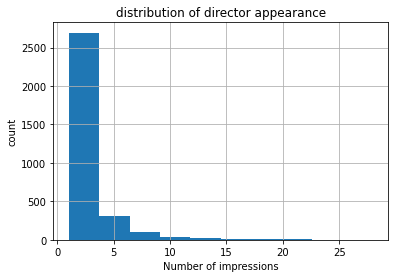

```python
df['director'].value_counts().hist();
plt.title('distribution of director appearance')
plt.xlabel('Number of impressions')
plt.ylabel('count')
plt.show()
```

## filter directors have participated in more than 3 movies

```python
df_accepted_dir=(df['director'].value_counts() > 3).to_frame()
df_accepted_dir.head()
```

|  | director |
| --- | --- |
| Steven Spielberg | True |
| Clint Eastwood | True |
| Ridley Scott | True |
| Ron Howard | True |
| Martin Scorsese | True |

```python
df_accepted_dir['acceptance']=df_accepted_dir['director']
df_accepted_dir.head()
```

|  | director | acceptance |
| --- | --- | --- |
| Steven Spielberg | True | True |
| Clint Eastwood | True | True |
| Ridley Scott | True | True |
| Ron Howard | True | True |
| Martin Scorsese | True | True |

```python
df_accepted_dir['director']=df_accepted_dir.index
df_accepted_dir.head()
```

|  | director | acceptance |
| --- | --- | --- |
| Steven Spielberg | Steven Spielberg | True |
| Clint Eastwood | Clint Eastwood | True |
| Ridley Scott | Ridley Scott | True |
| Ron Howard | Ron Howard | True |
| Martin Scorsese | Martin Scorsese | True |

```python
df['accepted_director']=df['director']
```

```python
acceptance=[]
for i in range(len(df['director'])):
    df['accepted_director'][i]=df_accepted_dir.query(f'director == "{df.director[i]}"')['acceptance'][0]
```

[output not shown]

```python
df_accepted_dir.query(f'director == "Colin Trevorrow"')['acceptance'][0]
```

```
False
```

```python
df['accepted_director'].head()
```

```
0    False
1     True
2     True
3     True
4     True
Name: accepted_director, dtype: object
```

```python
df_01 = df.query('release_year > 2000')
df_01.head(3)
```

|  | id | imdb_id | popularity | budget | revenue | original_title | cast | director | tagline | keywords | ... | genres | production_companies | release_date | vote_count | vote_average | release_year | budget_adj | revenue_adj | main_genres | accepted_director |
| --- | --- | --- | --- | --- | --- | --- | --- | --- | --- | --- | --- | --- | --- | --- | --- | --- | --- | --- | --- | --- | --- |
| 0 | 135397 | tt0369610 | 32.985763 | 150000000 | 1513528810 | Jurassic World | Chris Pratt\|Bryce Dallas Howard\|Irrfan Khan\|Vi... | Colin Trevorrow | The park is open. | monster\|dna\|tyrannosaurus rex\|velociraptor\|island | ... | Action\|Adventure\|Science Fiction\|Thriller | Universal Studios\|Amblin Entertainment\|Legenda... | 6/9/15 | 5562 | 6.5 | 2015 | 1.379999e+08 | 1.392446e+09 | Action | False |
| 1 | 76341 | tt1392190 | 28.419936 | 150000000 | 378436354 | Mad Max: Fury Road | Tom Hardy\|Charlize Theron\|Hugh Keays-Byrne\|Nic... | George Miller | What a Lovely Day. | future\|chase\|post-apocalyptic\|dystopia\|australia | ... | Action\|Adventure\|Science Fiction\|Thriller | Village Roadshow Pictures\|Kennedy Miller Produ... | 5/13/15 | 6185 | 7.1 | 2015 | 1.379999e+08 | 3.481613e+08 | Action | True |
| 2 | 262500 | tt2908446 | 13.112507 | 110000000 | 295238201 | Insurgent | Shailene Woodley\|Theo James\|Kate Winslet\|Ansel... | Robert Schwentke | One Choice Can Destroy You | based on novel\|revolution\|dystopia\|sequel\|dyst... | ... | Adventure\|Science Fiction\|Thriller | Summit Entertainment\|Mandeville Films\|Red Wago... | 3/18/15 | 2480 | 6.3 | 2015 | 1.012000e+08 | 2.716190e+08 | Adventure | True |

3 rows × 22 columns

```python
higt_vote_dir_01=df_01.query('accepted_director == True').groupby('director')["vote_average"].mean()
higt_vote_dir_01=higt_vote_dir_01.to_frame()
```

```python
higt_vote_dir_01['director']=higt_vote_dir_01.index
```

```python
higt_vote_dir_01['vote_average'].max()
```

```
7.6000000000000005
```

```python
higt_vote_dir_01.query('vote_average == 7.6000000000000005').director[0]
```

```
'Christopher Nolan'
```

## Christopher Nolan (director) has the highest vote average from 2001-2015 for directors has participated in more than 3 movies

### He turned out to be the highest of all time

```python
higt_vote_dir=df.query('accepted_director == True').groupby('director')["vote_average"].mean()
higt_vote_dir=higt_vote_dir.to_frame()
higt_vote_dir.head()
```

| director | vote_average |
| --- | --- |
| Abel Ferrara | 5.583333 |
| Adam Green | 5.400000 |
| Adam McKay | 6.357143 |
| Adam Shankman | 5.962500 |
| Adrian Lyne | 6.187500 |

```python
higt_vote_dir['director']=higt_vote_dir.index
higt_vote_dir.head()
```

| director | vote_average | director |
| --- | --- | --- |
| Abel Ferrara | 5.583333 | Abel Ferrara |
| Adam Green | 5.400000 | Adam Green |
| Adam McKay | 6.357143 | Adam McKay |
| Adam Shankman | 5.962500 | Adam Shankman |
| Adrian Lyne | 6.187500 | Adrian Lyne |

```python
higt_vote_dir['vote_average'].max()
```

```
7.6375
```

```python
higt_vote_dir.query('vote_average == 7.6375').director[0]
```

```
'Christopher Nolan'
```

```python
# Many similar questions can be extracted and answered in the same way by changing the attributes only
```

# conclusion

### The popular genre changes from year to year as bar chart (The most popular genres over time) and scatter plot (The most popular genres over time) shows, the long movies have higher popularity and higher vote average than short movies.

### The budget and popularity have a positive correlation with revenue.

### “Clyde Geronimi|Hamilton Luske|Wolfgang Reitherman "are the most successful director 1960-2015 highest revenue_adj (average) With 157,481,473,9 $

### Colin Trevorrow (director) has the most popular (average) movies from 2001-2015 With popularity average: 16.7

### Damien Chazelle (director) has the highest vote average from 2001-2015 with average 8.2

### Christopher Nolan (director) has the highest vote average from 2001-2015 for directors has participated in more than 3 movies with average 7.6

# limitation

## budget & revenue have many zero values, greater than 50% which makes it challenging to explore relations between other properties

## genres column have more than 1000 unique values, I think it will be more beneficial to make genres contain the primary genre of the movie not all keywords